# Análisis de datos: Caso Netflix

Realizaremos la carga, revisión, auditoria y limpieza de datos de un dataset de Netflix.

## 1. Carga de datos

Primero importamos Pandas; usaremos un CSV local en `netflix_titles.csv`. Si no existe, intentamos descargarlo desde una URL pública.

```python
import pandas as pd
from pathlib import Path

# Definir raíz del repo
REPO_ROOT = Path.cwd() if (Path.cwd() / "Data").exists() else Path.cwd().parent

# Ruta al archivo local
DATA_PATH = REPO_ROOT / "Data" / "netflix_titles.csv"

# URL alternativa
DATA_URL = "https://raw.githubusercontent.com/NAML26/portafolio/refs/heads/main/Data/netflix_titles.csv"

# Lógica: si existe local, lo carga; si no, lo descarga
if DATA_PATH.exists():
    df_original = pd.read_csv(DATA_PATH)
else:
    df_original = pd.read_csv(DATA_URL)
    DATA_PATH.parent.mkdir(parents=True, exist_ok=True)
    df_original.to_csv(DATA_PATH, index=False)

print("Filas y columnas originales:", df_original.shape)
df_original.head()
```

```
Filas y columnas originales: (8807, 12)
```

|  | show_id | type | title | director | cast | country | date_added | release_year | rating | duration | listed_in | description |
| --- | --- | --- | --- | --- | --- | --- | --- | --- | --- | --- | --- | --- |
| 0 | s1 | Movie | Dick Johnson Is Dead | Kirsten Johnson | NaN | United States | September 25, 2021 | 2020 | PG-13 | 90 min | Documentaries | As her father nears the end of his life, filmm... |
| 1 | s2 | TV Show | Blood & Water | NaN | Ama Qamata, Khosi Ngema, Gail Mabalane, Thaban... | South Africa | September 24, 2021 | 2021 | TV-MA | 2 Seasons | International TV Shows, TV Dramas, TV Mysteries | After crossing paths at a party, a Cape Town t... |
| 2 | s3 | TV Show | Ganglands | Julien Leclercq | Sami Bouajila, Tracy Gotoas, Samuel Jouy, Nabi... | NaN | September 24, 2021 | 2021 | TV-MA | 1 Season | Crime TV Shows, International TV Shows, TV Act... | To protect his family from a powerful drug lor... |
| 3 | s4 | TV Show | Jailbirds New Orleans | NaN | NaN | NaN | September 24, 2021 | 2021 | TV-MA | 1 Season | Docuseries, Reality TV | Feuds, flirtations and toilet talk go down amo... |
| 4 | s5 | TV Show | Kota Factory | NaN | Mayur More, Jitendra Kumar, Ranjan Raj, Alam K... | India | September 24, 2021 | 2021 | TV-MA | 2 Seasons | International TV Shows, Romantic TV Shows, TV ... | In a city of coaching centers known to train I... |

Las columnas más importantes son:

```python
for col in df_original.columns:
    print(f"- `{col}`")
```

```
- `show_id`
- `type`
- `title`
- `director`
- `cast`
- `country`
- `date_added`
- `release_year`
- `rating`
- `duration`
- `listed_in`
- `description`
```

## 2. Revisión inicial de los datos

Contestar 3 preguntas antes de limpiar datos:

1. ¿Qué columnas tengo?

```python
print("Columnas disponibles:")
print(df_original.columns.tolist())
```

```
Columnas disponibles:
['show_id', 'type', 'title', 'director', 'cast', 'country', 'date_added', 'release_year', 'rating', 'duration', 'listed_in', 'description']
```

2. ¿Qué tipo de dato tiene cada una?

```python
print("\nTipos de datos:")
display(df_original.dtypes.to_frame("tipo"))
```

```
Tipos de datos:
```

|  | tipo |
| --- | --- |
| show_id | str |
| type | str |
| title | str |
| director | str |
| cast | str |
| country | str |
| date_added | str |
| release_year | int64 |
| rating | str |
| duration | str |
| listed_in | str |
| description | str |

3. ¿Hay valores faltantes o algo que no cuadre?

```python
print("\nValores faltantes por columna:")
missing = df_original.isnull().sum().sort_values(ascending=False)
missing_pct = (missing / len(df_original) * 100).round(1)
display(pd.DataFrame({"faltantes": missing, "porcentaje": missing_pct}))
```

```
Valores faltantes por columna:
```

|  | faltantes | porcentaje |
| --- | --- | --- |
| director | 2634 | 29.9 |
| country | 831 | 9.4 |
| cast | 825 | 9.4 |
| date_added | 10 | 0.1 |
| rating | 4 | 0.0 |
| duration | 3 | 0.0 |
| show_id | 0 | 0.0 |
| type | 0 | 0.0 |
| title | 0 | 0.0 |
| release_year | 0 | 0.0 |
| listed_in | 0 | 0.0 |
| description | 0 | 0.0 |

El release_year se guarda en tipo int64, así que podemos pedirle un resumen numérico con .describe().T, lo que genera estadísticas descriptivas (conteo de número de registros con año válido, promedio, mínimo, máximo, percentiles).

```python
print("\nResumen numérico:")
display(df_original.describe().T)
```

```
Resumen numérico:
```

|  | count | mean | std | min | 25% | 50% | 75% | max |
| --- | --- | --- | --- | --- | --- | --- | --- | --- |
| release_year | 8807.0 | 2014.180198 | 8.819312 | 1925.0 | 2013.0 | 2017.0 | 2019.0 | 2021.0 |

Y podemos revisar la distribución por tipo de contenido:

```python
print("\nDistribución por tipo de contenido:")
display(df_original["type"].value_counts())
```

```
Distribución por tipo de contenido:
```

```
type
Movie      6131
TV Show    2676
Name: count, dtype: int64
```

## 3. Auditoría de calidad

La limpieza empieza con un diagnóstico. Revisamos:

1. **Duplicados**: filas repetidas que podrían inflar conteos.
2. **Valores imposibles**: edades negativas, tarifas negativas, clases fuera de rango.
3. **Cardinalidad**: cuántos valores distintos tiene cada columna categórica.
4. **Consistencia**: si los tipos de datos coinciden con el significado de la columna.

Esta auditoría nos dice *qué* hay que corregir y *por qué*.

```python
print("--- Auditoría de calidad ---")

# 1. Filas duplicadas
duplicados = df_original.duplicated().sum()
print("Filas duplicadas:", duplicados)

# 2. Rango de años de lanzamiento
print("\nRango de años de lanzamiento:")
print("\nAño mínimo:", df_original["release_year"].min())
print("Año máximo:", df_original["release_year"].max())

# 3. Consistencia en 'type'
print("\nDistribución de tipo de contenido:")
display(df_original["type"].value_counts())

# 4. Valores únicos en columnas clave
print("\nValores únicos por columna:")
for col in ["rating", "country", "duration", "listed_in"]:
    print(f"- {col}: {df_original[col].nunique()}")

# 5. Distribución de rating
print("\nDistribución de clasificación por edad:")
display(df_original["rating"].value_counts(dropna=False))

# 6. Distribución de países
print("\nDistribución de países (top 10):")
display(df_original["country"].value_counts(dropna=False).head(10))
```

```
--- Auditoría de calidad ---
Filas duplicadas: 0

Rango de años de lanzamiento:

Año mínimo: 1925
Año máximo: 2021

Distribución de tipo de contenido:
```

```
type
Movie      6131
TV Show    2676
Name: count, dtype: int64
```

```
Valores únicos por columna:
- rating: 17
- country: 748
- duration: 220
- listed_in: 514

Distribución de clasificación por edad:
```

```
rating
TV-MA       3207
TV-14       2160
TV-PG        863
R            799
PG-13        490
TV-Y7        334
TV-Y         307
PG           287
TV-G         220
NR            80
G             41
TV-Y7-FV       6
NaN            4
NC-17          3
UR             3
74 min         1
84 min         1
66 min         1
Name: count, dtype: int64
```

```
Distribución de países (top 10):
```

```
country
United States     2818
India              972
NaN                831
United Kingdom     419
Japan              245
South Korea        199
Canada             181
Spain              145
France             124
Mexico             110
Name: count, dtype: int64
```

## 4. Limpieza de datos

Vamos a limpiar paso a paso y documentar cada decisión.

### Decisiones de limpieza

1. **`duplicados`**: eliminamos filas repetidas porque no aportan información nueva.
2. **`date_added`**: convertimos a tipo `datetime` para poder analizar tendencias temporales.
3. **`country`**: muchos nulos; los reemplazamos por `Unknown` para no perder registros.
4. **`rating`**: algunos nulos; los reemplazamos por `Unrated` para mantener consistencia.
5. **`duration`**: homogenizamos espacios y formato para evitar inconsistencias.
6. **Exportación**: guardamos el dataset limpio como `netflix_clean.csv` para usarlo en la app de Streamlit.

> **Idea clave:** no existe una sola forma "correcta" de limpiar. Cada decisión cambia el análisis. Por eso documentamos el criterio.

## 5. Creación de variables nuevas

Muchas veces la información útil no viene lista en una sola columna. Hay que **construirla**.

```python
# --- Limpieza de datos ---
print("--- Limpieza de datos ---")

# 1. Eliminar duplicados
df_clean = df_original.drop_duplicates()
print("Filas después de eliminar duplicados:", df_clean.shape)

# 2. Convertir fechas
df_clean['date_added'] = pd.to_datetime(df_clean['date_added'], errors='coerce')

# 3. Rellenar valores faltantes en 'country'
df_clean['country'] = df_clean['country'].fillna("Unknown")

# 4. Rellenar valores faltantes en 'rating'
df_clean['rating'] = df_clean['rating'].fillna("Unrated")

# 5. Normalizar texto en 'duration'
df_clean['duration'] = df_clean['duration'].str.strip()

# --- Creación de variables nuevas ---
print("--- Creación de variables nuevas ---")

# Año y mes de incorporación
df_clean['year_added'] = df_clean['date_added'].dt.year
df_clean['month_added'] = df_clean['date_added'].dt.month

# Variables binarias
df_clean['has_director'] = df_clean['director'].notnull().astype(int)
df_clean['has_cast'] = df_clean['cast'].notnull().astype(int)

# Género principal
df_clean['main_genre'] = df_clean['listed_in'].str.split(',').str[0].str.strip()

# Duración separada
df_clean[['duration_int', 'duration_type']] = df_clean['duration'].str.extract(r'(\d+)\s*(\w+)')
df_clean['duration_int'] = pd.to_numeric(df_clean['duration_int'], errors='coerce')

# Agrupación de ratings
family_ratings = ['PG', 'TV-PG', 'TV-Y', 'TV-Y7', 'G']
df_clean['rating_group'] = df_clean['rating'].apply(lambda x: 'Family' if x in family_ratings else 'Adult')

# Indicador de títulos recientes (últimos 5 años)
df_clean['is_recent'] = (df_clean['release_year'] >= 2021).astype(int)

# --- Exploración de variables nuevas ---
print("--- Exploración de variables nuevas ---")

print("\nTítulos añadidos por año:")
print(df_clean['year_added'].value_counts().sort_index())

print("\nTítulos añadidos por mes:")
print(df_clean['month_added'].value_counts().sort_index())

print("\nProporción de títulos con director:")
print(df_clean['has_director'].value_counts(normalize=True).round(3))

print("\nProporción de títulos con elenco:")
print(df_clean['has_cast'].value_counts(normalize=True).round(3))

print("\nTop 10 géneros principales:")
print(df_clean['main_genre'].value_counts().head(10))

print("\nDuración promedio por tipo de contenido:")
print(df_clean.groupby('type')['duration_int'].mean().round(1))

print("\nDistribución por grupos de rating:")
print(df_clean['rating_group'].value_counts())

print("\nProporción de títulos recientes:")
print(df_clean['is_recent'].value_counts(normalize=True).round(3))

print("\nPaís con más películas por clasificación:")
print(df_clean.groupby('rating')['country'].value_counts().groupby(level=0).head(1))
```

```
--- Limpieza de datos ---
Filas después de eliminar duplicados: (8807, 12)
--- Creación de variables nuevas ---
```

```
--- Exploración de variables nuevas ---

Títulos añadidos por año:
year_added
2008.0       2
2009.0       2
2010.0       1
2011.0      13
2012.0       3
2013.0      10
2014.0      23
2015.0      73
2016.0     418
2017.0    1164
2018.0    1625
2019.0    1999
2020.0    1878
2021.0    1498
Name: count, dtype: int64

Títulos añadidos por mes:
month_added
1.0     727
2.0     557
3.0     734
4.0     759
5.0     626
6.0     724
7.0     819
8.0     749
9.0     765
10.0    755
11.0    697
12.0    797
Name: count, dtype: int64

Proporción de títulos con director:
has_director
1    0.701
0    0.299
```

[output cut: 8 more lines]

```
Top 10 géneros principales:
main_genre
Dramas                      1600
Comedies                    1210
Action & Adventure           859
Documentaries                829
International TV Shows       774
Children & Family Movies     605
Crime TV Shows               399
Kids' TV                     388
Stand-Up Comedy              334
Horror Movies                275
Name: count, dtype: int64

Duración promedio por tipo de contenido:
```

```
type
Movie      99.6
TV Show     1.8
Name: duration_int, dtype: float64

Distribución por grupos de rating:
rating_group
Adult     6975
Family    1832
Name: count, dtype: int64

Proporción de títulos recientes:
is_recent
0    0.933
1    0.067
Name: proportion, dtype: float64

País con más películas por clasificación:
```

```
rating    country
66 min    United States      1
74 min    United States      1
84 min    United States      1
G         United States     29
NC-17     United States      1
NR        United States     35
PG        United States    164
PG-13     United States    289
R         United States    440
TV-14     India            550
TV-G      United States     82
TV-MA     United States    928
TV-PG     United States    251
TV-Y      United States     87
TV-Y7     United States    101
TV-Y7-FV  Canada             1
UR        France             1
Unrated   Italy              1
Name: count, dtype: int64
```

### Exportar el dataset limpio

Guardamos `df_clean` (ya con todas las variables nuevas) como `netflix_clean.csv`, para usarlo directamente en la app de Streamlit sin tener que repetir la limpieza.

```python
from pathlib import Path

# Guardar en la misma carpeta 'Data' que usamos para el CSV original
OUTPUT_PATH = REPO_ROOT / "Data" / "netflix_clean.csv"
df_clean.to_csv(OUTPUT_PATH, index=False)

print(f"Dataset limpio guardado en: {OUTPUT_PATH}")
print("Filas y columnas guardadas:", df_clean.shape)
```

```
Dataset limpio guardado en: /home/ubuntu/Data/netflix_clean.csv
Filas y columnas guardadas: (8807, 21)
```

## 6. Visualizaciones exploratorias

Las tablas resumen números, pero las gráficas ayudan a **ver patrones** más rápido.

```python
!pip install matplotlib seaborn statsmodels scikit-learn
```

```
--- Visualizaciones exploratorias Netflix ---
```

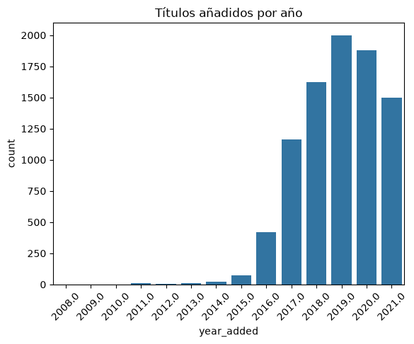

[figure not shown]

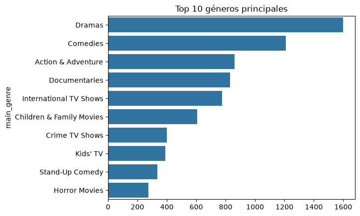

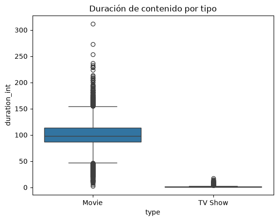

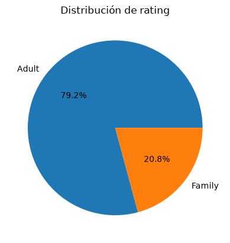

[figure not shown]

```python
import matplotlib.pyplot as plt
import seaborn as sns

print("--- Visualizaciones exploratorias Netflix ---")

# Títulos añadidos por año
sns.countplot(data=df_clean, x='year_added', order=sorted(df_clean['year_added'].dropna().unique()))
plt.title("Títulos añadidos por año")
plt.xticks(rotation=45)
plt.show()

# Títulos añadidos por mes
sns.countplot(data=df_clean, x='month_added', order=range(1, 13))
plt.title("Títulos añadidos por mes")
plt.show()

# Top 10 géneros principales
top_genres = df_clean['main_genre'].value_counts().head(10)
sns.barplot(x=top_genres.values, y=top_genres.index)
plt.title("Top 10 géneros principales")
plt.show()

# Duración por tipo
sns.boxplot(data=df_clean, x='type', y='duration_int')
plt.title("Duración de contenido por tipo")
plt.show()

# Distribución de rating (Family vs Adult)
df_clean['rating_group'].value_counts().plot.pie(autopct='%1.1f%%')
plt.title("Distribución de rating")
plt.ylabel("")
plt.show()

# Géneros en títulos recientes
recent_genres = df_clean[df_clean['is_recent'] == 1]['main_genre'].value_counts().head(10)
sns.barplot(x=recent_genres.values, y=recent_genres.index)
plt.title("Top géneros en títulos recientes (últimos 5 años)")
plt.show()
```

## 7. Regresión logística de contenido reciente

Ajustamos un modelo logístico para interpretar qué variables se asocian con que un título sea reciente (`is_recent`). Antes de ajustar, corregimos dos problemas que aparecían en la versión original:

- **Valores faltantes en `duration_int`** (la limpieza no rellenó los nulos de `duration`): se eliminan esas filas antes de ajustar, para que el modelo de interpretación y el de evaluación usen exactamente las mismas filas.
- **Separación cuasi-perfecta en `main_genre`**: géneros poco frecuentes, o géneros donde `is_recent` es siempre 0 o siempre 1 (como `Classic Movies`), se agrupan en `"Otros"` para evitar coeficientes y errores estándar disparados (y el `ConvergenceWarning`).

```python
import statsmodels.formula.api as smf
from sklearn.model_selection import train_test_split
from sklearn.linear_model import LogisticRegression
from sklearn.metrics import accuracy_score, confusion_matrix, classification_report, roc_auc_score


def ajustar_modelo_logit(df, min_freq_genero=50):
    """Ajusta un modelo de regresión logística sobre todo el dataset,
    para interpretar el efecto de cada variable.

    Los géneros con menos de `min_freq_genero` observaciones, o con `is_recent`
    constante, se agrupan en 'Otros' para evitar separación cuasi-perfecta.

    Devuelve el DataFrame reducido a las columnas usadas por el modelo,
    para reutilizarlo en la etapa de evaluación.
    """
    print("--- Regresión logística de contenido reciente ---")

    columnas_modelo = [
        "is_recent", "type", "main_genre", "rating_group",
        "duration_int", "has_director", "has_cast",
    ]
    modelo_df = df[columnas_modelo].copy()

    # 'duration' tiene valores faltantes que no se rellenaron en la limpieza,
    # así que 'duration_int' puede traer NaN. Los quitamos aquí para que el
    # modelo de interpretación y el de evaluación usen las mismas filas.
    filas_antes = len(modelo_df)
    modelo_df = modelo_df.dropna()
    filas_eliminadas = filas_antes - len(modelo_df)
    if filas_eliminadas:
        print(f"Filas eliminadas por valores faltantes: {filas_eliminadas}")

    # Agrupar géneros problemáticos en 'Otros'. Dos motivos causan separación
    # cuasi-perfecta y hay que cubrir ambos:
    #   (a) baja frecuencia: pocas observaciones, fácil que salgan todas del mismo lado
    #   (b) pureza: aunque tenga muchas observaciones, is_recent es constante
    #       dentro de esa categoría (ej. 'Classic Movies' es siempre antiguo)
    frecuencia_genero = modelo_df["main_genre"].value_counts()
    generos_poco_frecuentes = set(frecuencia_genero[frecuencia_genero < min_freq_genero].index)

    pureza_genero = modelo_df.groupby("main_genre")["is_recent"].nunique()
    generos_puros = set(pureza_genero[pureza_genero < 2].index)

    generos_a_agrupar = generos_poco_frecuentes | generos_puros
    modelo_df["main_genre"] = modelo_df["main_genre"].where(
        ~modelo_df["main_genre"].isin(generos_a_agrupar), "Otros"
    )
    if generos_a_agrupar:
        print(
            f"Géneros agrupados en 'Otros': {len(generos_a_agrupar)} "
            f"({len(generos_poco_frecuentes)} por baja frecuencia, "
            f"{len(generos_puros - generos_poco_frecuentes)} por ser puros/constantes)"
        )

    formula = (
        "is_recent ~ C(type) + C(main_genre) + C(rating_group) "
        "+ duration_int + has_director + has_cast"
    )
    modelo = smf.logit(formula, data=modelo_df).fit(disp=0)

    display(modelo.summary())
    print("\nPseudo R-cuadrado:", round(modelo.prsquared, 4))

    return modelo_df


def evaluar_modelo(modelo_df, test_size=0.2, random_state=42):
    """Entrena un modelo logístico sobre un split train/test y evalúa su desempeño
    fuera de muestra (accuracy, AUC-ROC, matriz de confusión, reporte de clasificación).

    Usa scikit-learn (no statsmodels) para poder aplicar class_weight='balanced':
    'is_recent' solo es 1 en ~7% de las filas, así que sin ponderar por clase el
    modelo aprende a predecir siempre 0 (accuracy alta pero recall de 'Reciente' = 0).
    """
    print("--- Evaluación con train/test split ---")

    X = pd.get_dummies(modelo_df.drop(columns=["is_recent"]), drop_first=True).astype(float)
    y = modelo_df["is_recent"]

    X_train, X_test, y_train, y_test = train_test_split(
        X, y, test_size=test_size, random_state=random_state, stratify=y
    )

    # class_weight='balanced' pondera cada clase por el inverso de su frecuencia,
    # para que la clase minoritaria ('Reciente') pese tanto como la mayoritaria.
    modelo_train = LogisticRegression(class_weight="balanced", max_iter=1000)
    modelo_train.fit(X_train, y_train)

    probs = modelo_train.predict_proba(X_test)[:, 1]
    preds = modelo_train.predict(X_test)

    print("Exactitud en prueba:", round(accuracy_score(y_test, preds), 4))
    print("AUC-ROC en prueba:", round(roc_auc_score(y_test, probs), 4))

    print("\nMatriz de confusión:")
    print(pd.DataFrame(
        confusion_matrix(y_test, preds),
        index=["Real: Antiguo", "Real: Reciente"],
        columns=["Pred: Antiguo", "Pred: Reciente"],
    ))

    print("\nReporte de clasificación:")
    print(classification_report(y_test, preds, target_names=["Antiguo", "Reciente"]))

    return modelo_train
```

## 8. Evaluación con train/test split

Corremos las dos funciones: la primera ajusta e interpreta el modelo completo; la segunda lo entrena sobre un split train/test y evalúa qué tan bien predice fuera de muestra.

```python
modelo_df_reducido = ajustar_modelo_logit(df_clean)
modelo_entrenado = evaluar_modelo(modelo_df_reducido)
```

```
--- Regresión logística de contenido reciente ---
Filas eliminadas por valores faltantes: 3
Géneros agrupados en 'Otros': 17 (16 por baja frecuencia, 1 por ser puros/constantes)
```

Logit Regression Results

| Dep. Variable: | is_recent | No. Observations: | 8804 |
| --- | --- | --- | --- |
| Model: | Logit | Df Residuals: | 8779 |
| Method: | MLE | Df Model: | 24 |
| Date: | Tue, 07 Jul 2026 | Pseudo R-squ.: | 0.04997 |
| Time: | 00:40:59 | Log-Likelihood: | -2061.3 |
| converged: | True | LL-Null: | -2169.7 |
| Covariance Type: | nonrobust | LLR p-value: | 5.552e-33 |

|  | coef | std err | z | P>\|z\| | [0.025 | 0.975] |
| --- | --- | --- | --- | --- | --- | --- |
| Intercept | -2.5553 | 0.402 | -6.364 | 0.000 | -3.342 | -1.768 |
| C(type)[T.TV Show] | 2.5002 | 0.804 | 3.109 | 0.002 | 0.924 | 4.076 |
| C(main_genre)[T.Anime Series] | -1.2636 | 0.800 | -1.579 | 0.114 | -2.832 | 0.305 |
| C(main_genre)[T.British TV Shows] | -2.0719 | 0.809 | -2.561 | 0.010 | -3.658 | -0.486 |
| C(main_genre)[T.Children & Family Movies] | 0.7212 | 0.277 | 2.607 | 0.009 | 0.179 | 1.264 |
| C(main_genre)[T.Comedies] | -0.0822 | 0.224 | -0.366 | 0.714 | -0.522 | 0.357 |
| C(main_genre)[T.Crime TV Shows] | -1.7912 | 0.786 | -2.278 | 0.023 | -3.332 | -0.250 |
| C(main_genre)[T.Documentaries] | 0.1419 | 0.250 | 0.567 | 0.571 | -0.349 | 0.633 |
| C(main_genre)[T.Docuseries] | -1.1529 | 0.793 | -1.454 | 0.146 | -2.707 | 0.401 |
| C(main_genre)[T.Dramas] | -0.1935 | 0.216 | -0.897 | 0.370 | -0.616 | 0.229 |
| C(main_genre)[T.Horror Movies] | 0.3375 | 0.304 | 1.109 | 0.267 | -0.259 | 0.934 |
| C(main_genre)[T.International Movies] | 0.2637 | 0.424 | 0.622 | 0.534 | -0.567 | 1.095 |
| C(main_genre)[T.International TV Shows] | -1.5079 | 0.776 | -1.943 | 0.052 | -3.029 | 0.013 |
| C(main_genre)[T.Kids' TV] | -1.2809 | 0.797 | -1.608 | 0.108 | -2.842 | 0.280 |
| C(main_genre)[T.Movies] | 0.7319 | 0.581 | 1.260 | 0.208 | -0.406 | 1.870 |
| C(main_genre)[T.Otros] | -1.3012 | 0.732 | -1.778 | 0.075 | -2.736 | 0.133 |
| C(main_genre)[T.Reality TV] | -0.8347 | 0.804 | -1.039 | 0.299 | -2.410 | 0.741 |
| C(main_genre)[T.Stand-Up Comedy] | -0.2619 | 0.360 | -0.727 | 0.467 | -0.968 | 0.444 |
| C(main_genre)[T.TV Comedies] | -1.2164 | 0.811 | -1.499 | 0.134 | -2.806 | 0.374 |
| C(main_genre)[T.TV Dramas] | -1.7536 | 0.879 | -1.995 | 0.046 | -3.476 | -0.031 |
| C(main_genre)[T.Thrillers] | 0.3317 | 0.544 | 0.610 | 0.542 | -0.735 | 1.398 |
| C(rating_group)[T.Family] | -0.4926 | 0.145 | -3.405 | 0.001 | -0.776 | -0.209 |
| duration_int | -0.0013 | 0.003 | -0.470 | 0.638 | -0.007 | 0.004 |
| has_director | 0.1045 | 0.180 | 0.579 | 0.562 | -0.249 | 0.458 |
| has_cast | -0.4798 | 0.146 | -3.294 | 0.001 | -0.765 | -0.194 |

```
Pseudo R-cuadrado: 0.05
--- Evaluación con train/test split ---
```

```
Exactitud en prueba: 0.6343
AUC-ROC en prueba: 0.6495

Matriz de confusión:
                Pred: Antiguo  Pred: Reciente
Real: Antiguo            1045             598
Real: Reciente             46              72

Reporte de clasificación:
              precision    recall  f1-score   support

     Antiguo       0.96      0.64      0.76      1643
    Reciente       0.11      0.61      0.18       118

    accuracy                           0.63      1761
   macro avg       0.53      0.62      0.47      1761
weighted avg       0.90      0.63      0.73      1761
```

## 9. Resumen final

```python
print("--- Resumen final ---")
print("""
1. Netflix ha crecido de forma marcada en ciertos años y meses, con picos de incorporación.
2. Los géneros dominantes cambian con el tiempo, y algunos se concentran en títulos recientes.
3. Las series muestran diferencias de duración frente a películas.
4. El contenido adulto ha aumentado en proporción en los últimos años.
5. La completitud de metadata (director, elenco) también varía entre títulos antiguos y recientes.

La parte más importante no es solo correr el modelo, sino saber leer la historia que cuentan
los datos sobre cómo Netflix construye su catálogo.
""")
```

```
--- Resumen final ---

1. Netflix ha crecido de forma marcada en ciertos años y meses, con picos de incorporación.
2. Los géneros dominantes cambian con el tiempo, y algunos se concentran en títulos recientes.
3. Las series muestran diferencias de duración frente a películas.
4. El contenido adulto ha aumentado en proporción en los últimos años.
5. La completitud de metadata (director, elenco) también varía entre títulos antiguos y recientes.

La parte más importante no es solo correr el modelo, sino saber leer la historia que cuentan
los datos sobre cómo Netflix construye su catálogo.
```